# Assignment_9

We’ll be looking at the “GradSchool_Admissions” data set. We first gotta set up and clean the data set:

```r
library(tidyverse)
library(easystats)
library(janitor)
library(modelr)
library(GGally)
library(ggpubr)
library(scales)
library(rlang)
install.packages("rlang")


# Cleaning Data:
df <- read_csv("C:/Users/email/Data_Course_MILLS/Assignments/Assignment_9/Data/GradSchool_Admissions.csv")
df <- df %>%
  mutate(admit = case_when(admit == 1 ~ TRUE,
                           TRUE ~ FALSE))
df$Student <- seq.int(nrow(df))
df <- df[, c(5, 1, 2, 3, 4)]
```

Now here’s a glimpse of the data:

```r
glimpse(df)
```

```
## Rows: 400
## Columns: 5
## $ Student <int> 1, 2, 3, 4, 5, 6, 7, 8, 9, 10, 11, 12, 13, 14, 15, 16, 17, 18,~
## $ admit   <lgl> FALSE, TRUE, TRUE, TRUE, FALSE, TRUE, TRUE, FALSE, TRUE, FALSE~
## $ gre     <dbl> 380, 660, 800, 640, 520, 760, 560, 400, 540, 700, 800, 440, 76~
## $ gpa     <dbl> 3.61, 3.67, 4.00, 3.19, 2.93, 3.00, 2.98, 3.08, 3.39, 3.92, 4.~
## $ rank    <dbl> 3, 3, 1, 4, 4, 2, 1, 2, 3, 2, 4, 1, 1, 2, 1, 3, 4, 3, 2, 1, 3,~
```

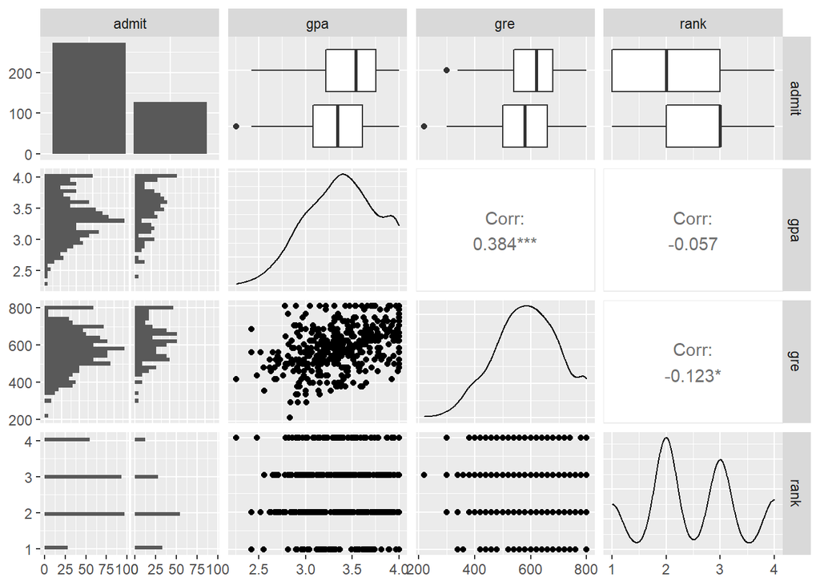

```r
df %>%
  select(admit, gpa, gre,rank) %>%
  ggpairs()
```

I want to focus on the GPA’s among these students and see specifically what types of students have the best GPA’s. First, lets look at the distribution of GPAs among different ranks of undergraduate programs:

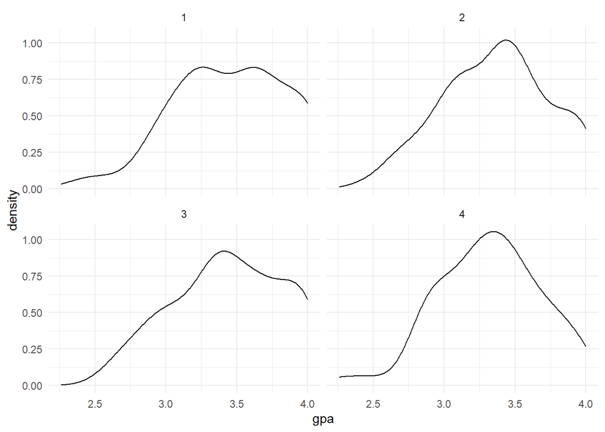

```r
df %>%
  ggplot(aes(x=gpa)) +
  geom_density() +
  facet_wrap(~rank) +
  theme_minimal()
```

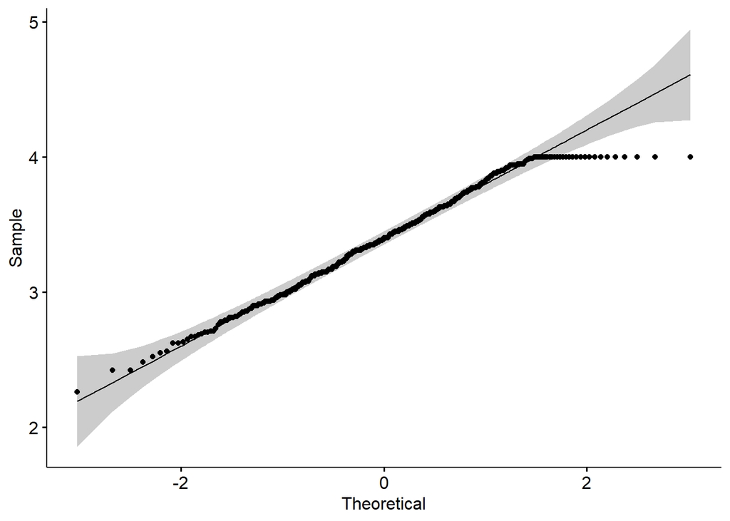

```r
# Testing normality
ggpubr::ggqqplot(df$gpa)
```

Based on this quick test, GPA looks like a good variable to test.

## Models

```r
names(df)
```

```
## [1] "Student" "admit"   "gre"     "gpa"     "rank"
```

```r
mod1 <- glm(data = df, formula = gpa ~ admit + gre)

mod2 <- glm(data = df, formula = gpa ~ admit * gre)

mod3 <- glm(data = df, formula = gpa ~ admit * gre * rank)
```

I’m going to compare the performance of each of these models against each other:

```r
comps <- compare_performance(mod1, mod2, mod3, rank = TRUE)
comps
```

```
## # Comparison of Model Performance Indices
##
## Name | Model |    R2 |  RMSE | Sigma | AIC weights | BIC weights | Performance-Score
## ------------------------------------------------------------------------------------
## mod2 |   glm | 0.166 | 0.347 | 0.349 |       0.600 |       0.175 |            75.96%
## mod1 |   glm | 0.160 | 0.348 | 0.350 |       0.384 |       0.825 |            41.24%
## mod3 |   glm | 0.167 | 0.347 | 0.350 |       0.016 |    1.60e-06 |            40.00%
```

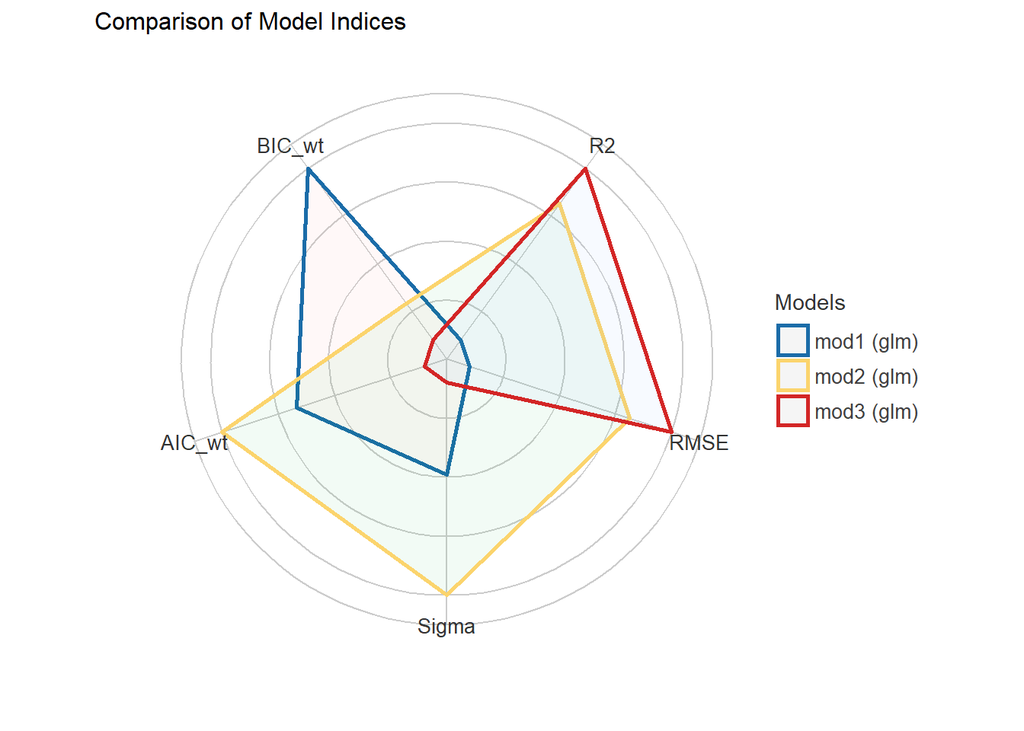

```r
comps %>% plot()
```

As you can see here, model 2 is superior compared to models 1 and 3. It is also a good model to test because of it’s simplicity.

From these models, I am going to take a look at predictions:

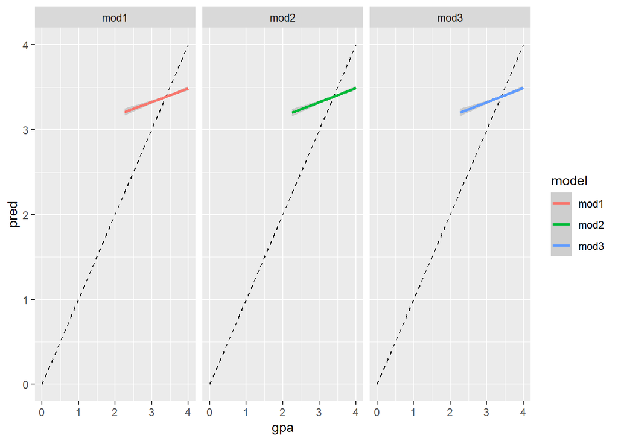

```r
df %>%
  gather_predictions(mod1, mod2, mod3) %>%
  ggplot(aes(x=gpa, y=pred, color=model)) +
  geom_segment(aes(x=0, y=0, xend=4, yend=4),
               linetype = 2, color="black", alpha=0.5) +
  geom_smooth(method = "lm", se=TRUE) +
  facet_wrap(~model)
```

We can see here that the predictions among all three models are extremely similar. So even though Model 2 performs better than the other models, its predictions for the future are the same as the other models… for some reason.

Obviously, a higher GPA will lead to a better chance at being admitted into a graduate program.